# ISB bigquery for TCGA: Some Bioconductor strategies

Vince Carey

June 22, 2016

## Road map

- Basic overview on cancer genomics cloud approach to level 3 TCGA
- BigQuery intro by doing
- A bladder cancer CDK use case from ISB
- An interactive oncoPrint
- Exercises and commentary

## Overview

- TCGA is a collection of omics assay results and clinical characteristics of donors of tumor tissue on a wide variety of cancers
- The public data has so far been a perennial source of logistical challenges for interested bioinformaticians
  - Access is sufficiently complex to warrant several independently developed Bioconductor packages
  - Coordination of data structures and vocabularies consumes significant effort
- NCI Cancer Genomic Cloud pilots: “Democratize” access, federate management and analysis methods

## The ISB Cancer Genomic Cloud Pilot: A way in via Google BigQuery

You need an authentication token, ‘my_billing’ contains secret info

```r
getBQ = function ()
{
    library(dplyr)
    library(bigrquery)
    my_billing = <secret>
    src_bigquery("isb-cgc", "tcga_201510_alpha", billing = my_billing)
}
```

## Let’s try it, dplyr idiom

```r
bq = getBQ()
bq
```

```
## src:  bigquery [isb-cgc:tcga_201510_alpha]
## tbls: Annotations, Biospecimen_data, Clinical_data, Copy_Number_segments,
##   DNA_Methylation_betas, miRNA_expression, mRNA_BCGSC_HiSeq_RPKM,
##   mRNA_UNC_HiSeq_RSEM, Protein_RPPA_data, Somatic_Mutation_calls
```

## Access now available for all tumor types

```r
LUAD_Clin = bq %>% tbl("Clinical_data") %>%
      filter(Study=="LUAD") %>% as.data.frame()
dim(LUAD_Clin)
```

```
## [1] 522  65
```

- dplyr idiom is not necessary
- `bigrquery query_exec()` will submit BigQuery-compliant SQL

## Some variables (lots of NA, blanks)

```r
datatable(LUAD_Clin[,c(1,49,54)], options=list(lengthMenu=c(3,5)))
```

|  | ParticipantBarcode | pathologic_T | primary_therapy_outcome_success |
| --- | --- | --- | --- |
| 1 | TCGA-67-3772 | T2 |  |
| 2 | TCGA-67-3774 | T2 |  |
| 3 | TCGA-67-3776 | T2 |  |
| 4 | TCGA-L9-A8F4 | T2a |  |
| 5 | TCGA-44-5643 | T2b |  |
| 6 | TCGA-44-5644 | T2a | Complete Remission/Response |
| 7 | TCGA-44-5645 | T1 | Complete Remission/Response |
| 8 | TCGA-99-8028 | T1a | Complete Remission/Response |
| 9 | TCGA-05-4244 | T2 |  |
| 10 | TCGA-05-4245 | T2 |  |

[output cut: 512 more lines]

## Use case from ISB BigQuery walkthrough

For bladder cancer patients that have mutations in the CDKN2A (cyclin-dependent kinase inhibitor 2A) gene, what types of mutations are they, what is their gender, vital status, and days to death - and for 3 downstream genes (MDM2 (MDM2 proto-oncogene), TP53 (tumor protein p53), CDKN1A (cyclin-dependent kinase inhibitor 1A)), what are the gene expression levels for each patient?

## Break it down

- Bladder cancer: Study is BLCA
- Mutation data: filter to CDKN2A and tabulate type
- Clinical data: merge
- Expression data: MDM2, TP53, CDKN1A on these patients

## Mutations – NB order of operations can affect timing/timeout

```r
mudf = bq %>% tbl("Somatic_Mutation_calls") %>%
  filter(Study=="BLCA") %>% filter(Hugo_Symbol == "CDKN2A") %>%
  select(ParticipantBarcode, Study, Hugo_Symbol,
              Variant_Type, Variant_Classification) %>%
              as.data.frame()
head(mudf,3)
```

```
##   ParticipantBarcode Study Hugo_Symbol Variant_Type Variant_Classification
## 1       TCGA-XF-AAN3  BLCA      CDKN2A          SNP      Missense_Mutation
## 2       TCGA-ZF-A9R4  BLCA      CDKN2A          SNP      Missense_Mutation
## 3       TCGA-ZF-AA4N  BLCA      CDKN2A          SNP            Splice_Site
```

## Expression

```r
exdf = bq %>% tbl("mRNA_UNC_HiSeq_RSEM") %>%
  filter(Study=="BLCA") %>% filter(HGNC_gene_symbol
          %in% c("MDM2", "TP53", "CDKN2A", "CDKN1A")) %>%
  select(ParticipantBarcode, Study, HGNC_gene_symbol, normalized_count) %>%
              as.data.frame()
```

## Condense multiple CDKN2A mutations of the same type in an individual

```r
o = order(mudf$ParticipantBarcode, mudf$Variant_Classification)
mudf = mudf[o,]
cls = with(mudf, split(Variant_Classification, ParticipantBarcode))
todrop = lapply(cls, duplicated)
mudf = mudf[-which(unlist(todrop)),]
```

## Merge mutation and expression data

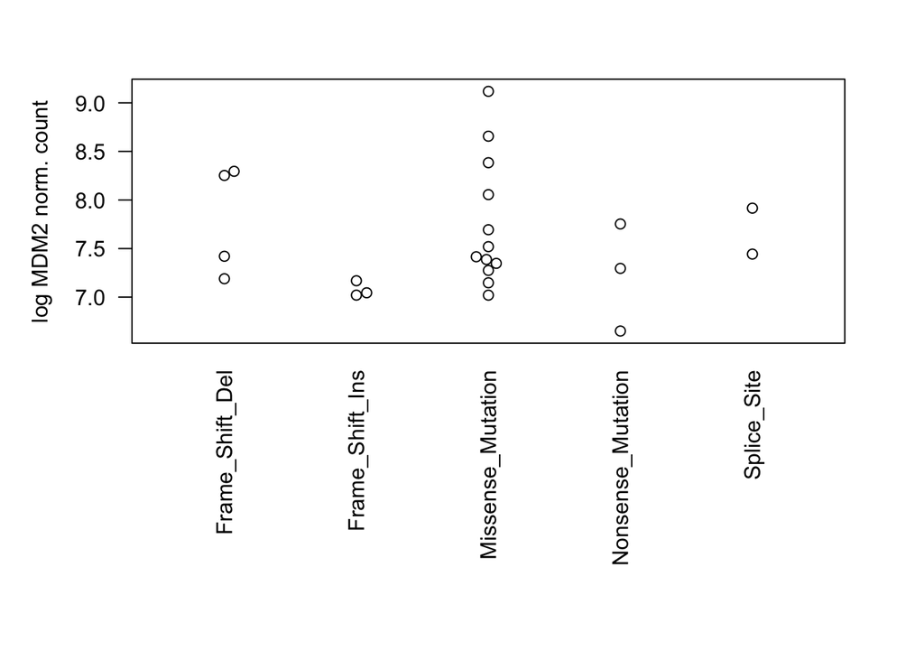

```r
muex = merge(mudf, exdf, by="ParticipantBarcode", all.x=TRUE)
par(mar=c(12,5,3,3),las=2)
with(muex[muex$HG=="MDM2",],
   beeswarm(split(log(normalized_count+1), Variant_Classification),
     ylab="log MDM2 norm. count"))
```

## Exercises

- See the [walkthrough at ISB](http://isb-cancer-genomics-cloud.readthedocs.io/en/latest/sections/progapi/bigqueryGUI/WalkthroughOfGoogleBigQuery.html)
- Write the BigQuery SQL to carry out the merge and use `query_exec` to verify that the R operations agree with the native operations
- Merge the clinical data and test for an effect of CDKN2A mutation class on survival time distribution
- Define and execute a test of the null hypothesis that the mean of (MDM2, TP53, CDKN1A) is constant over CDKN2A mutation classes
- Generalize the computing framework for this test to allow free selection of upstream mutation carriers and downstream expression target patterns for any TCGA tumor family

## Interactive oncoprint

To achieve the following display, use

```
library(cgcR)
bq = getBQ() # set your project properly
isbApp(bq) # then pick LGG as the tumor to study
```

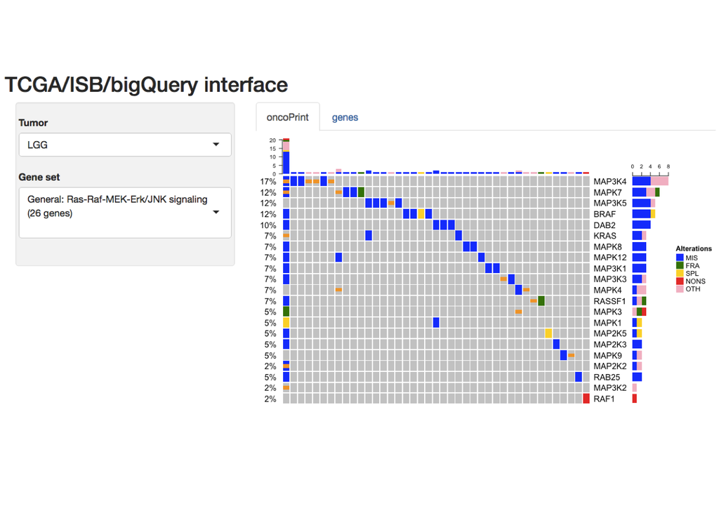

## Exercises

- Add additional gene sets to the isbApp
- Introduce a systematic approach to labeling mutation classes
- Improve the heatmap tile generation/coding
- Add hoverOver functionality so that relevant information on the sample is produced to help interpret mutation patterns – might take a lot of transformation of code to ggvis or ggplot2/plotly/rbokeh

## Comments

- Clinical data curation still important
- Molecular data quality assessment/QC still important
- See `MultiAssayExperiment` package and TCGA archive in S3 bucket
- Additional BigQuery project in ISB CGC: `ccle_201602_alpha` but lacks chemosensitivity profiles